# Enhanced cholera surveillance as a tool for improving vaccination campaign efficiency (2023 resubmission)

31 October 2023

### Main results of VIMC surveillance project for the manuscript.

### **Figure 1.** Model Illustration

- IR: Incidence rate; CR: Confirmation rate.

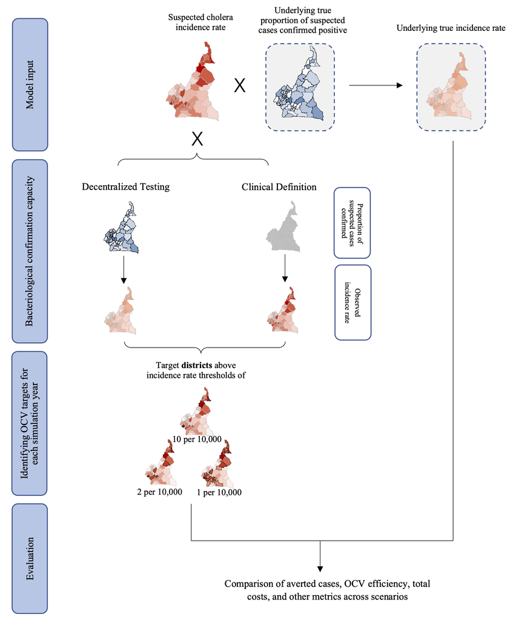

### **Table 1.** Projected FVPs, cases averted, proportion of true cases averted (among all true cases), and OCV campaign efficiency (2022 ~ 2035).

- Numbers in the parentheses are **medians** and 95% CIs.

| Threshold | Fully vaccinated population (million) Clinical Definition | Fully vaccinated population (million) Decentral. Testing | Averted cases (million) Clinical Definition | Averted cases (million) Decentral. Testing | OCV Efficiency (averted cases / 1,000 FVP) Clinical Definition | OCV Efficiency (averted cases / 1,000 FVP) Decentral. Testing | Percent of true cases averted Clinical Definition | Percent of true cases averted Decentral. Testing |
| --- | --- | --- | --- | --- | --- | --- | --- | --- |
| 1/10,000 per year | 391.8 (378.8-412.2) | 274.6 (261.1-285.8) | 0.76 (0.69-0.84) | 0.71 (0.64-0.8) | 1.9 (1.7-2.2) | 2.6 (2.4-2.9) | 44.7 (44.3-45.3) | 41.8 (41-42.9) |
| 2/10,000 per year | 275.2 (264.5-283.9) | 165.2 (153.9-179.4) | 0.7 (0.64-0.79) | 0.62 (0.55-0.71) | 2.6 (2.3-2.8) | 3.7 (3.4-4.2) | 41.5 (40.8-42.7) | 36.5 (35.4-38.1) |
| 10/10,000 per year | 65.2 (59.8-71) | 30.1 (24.4-37.9) | 0.45 (0.38-0.53) | 0.33 (0.26-0.41) | 6.9 (6-7.8) | 10.8 (9.4-12.6) | 26.5 (24.4-28.5) | 19.2 (16.7-22.3) |

### **Table 2.** Cost effectiveness: cost per averted case

(OCV campaign cost, testing cost, or total cost per averted cases, summarized across all countries, this is also ICER, using “no vaccination” scenario as REF.)

| Threshold | OCV cost per averted case Clinical Definition | OCV cost per averted case Decentral. Testing | Test cost per averted case Clinical Definition | Test cost per averted case Decentral. Testing | Total cost per averted case Clinical Definition | Total cost per averted case Decentral. Testing |
| --- | --- | --- | --- | --- | --- | --- |
| 1/10,000 per year | 2452 (2153-2707) | 1819 (1643-2006) | 0 (0-0) | 10 (9-11) | 2452 (2153-2707) | 1829 (1653-2017) |
| 2/10,000 per year | 1841 (1658-2042) | 1260 (1130-1400) | 0 (0-0) | 13 (12-14) | 1841 (1658-2042) | 1272 (1142-1413) |
| 10/10,000 per year | 685 (603-780) | 438 (376-501) | 0 (0-0) | 31 (25-39) | 685 (603-780) | 468 (405-543) |

### **Table 3.** Cost of test and ocv trade-offs (summarized across countries)

[output not shown]

### **Figure 2.** Country-level cost & cost-effectiveness

(A): Averted cases; (B) total costs; (C) OCV cost per averted case; (D) OCV cost saved ~ test cost spent

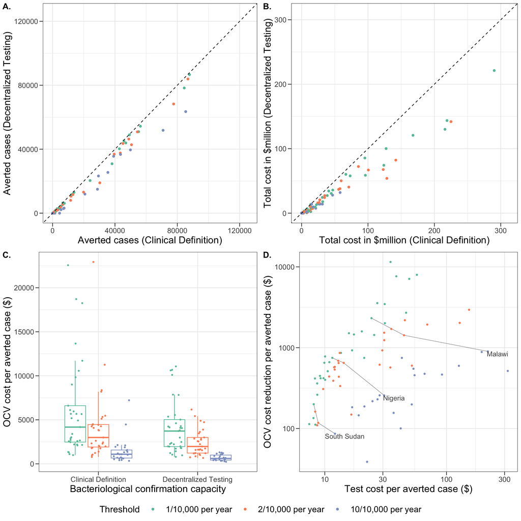

```
##   ISO threshold admin_level ocv_cost_per_ac_district_estimate_median
## 1 NGA     1e-04      admin2                                1805.9669
## 2 NGA     1e-03      admin2                                 352.6975
##   ocv_cost_per_ac_no_estimate_median test_cost_per_ac_median
## 1                          2555.3208                11.52665
## 2                           609.4578                30.77517
##   ocv_cost_saved_per_ac_median spend_cost_ratio_median
## 1                     749.3539               65.010558
## 2                     256.7603                8.343098
```

### **Table 4.** Proportion of fully vaccinated population in high-incidence rate areas (summarized across countries)

| Threshold | Proportion of vaccinated pop living in high IR areas Clinical Definition | Proportion of vaccinated pop living in high IR areas Decentral. Testing | Proportion of vaccinated pop living in high IR areas Central. Testing |
| --- | --- | --- | --- |
| 1/10,000 per year | 67.1 (63.4-71.2) | 98.7 (97.4-99.5) | 96.3 (93-97.9) |
| 2/10,000 per year | 56.9 (52.9-62.6) | 98.1 (95.5-99.3) | 95.5 (91.7-97.6) |
| 10/10,000 per year | 43.1 (35.2-51.8) | 97.8 (92.8-100) | 94.3 (83-99) |

### **Figure 3.** Proportion of FVPs in high-incidence rate areas (country level)

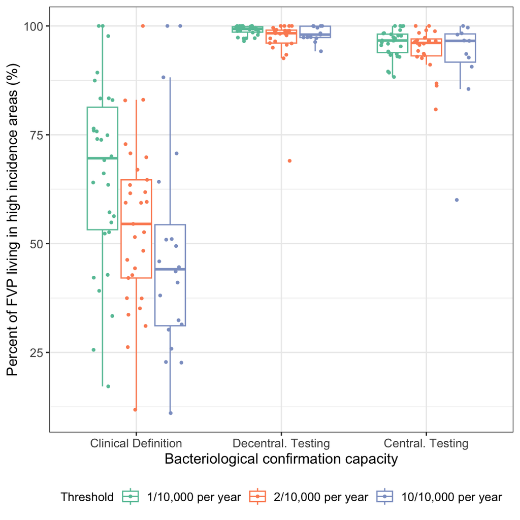

### **Figure S1.** Comparison of OCV efficiency across scenarios

- Each of the dot in the boxplot represents the **median** efficiency of each country.

Get the ratios (in the draft) of fvp, ac, vaccine efficiency between “Clinical definitions” and “Decentralized testing”:

```
## # A tibble: 3 × 6
## # Groups:   threshold [3]
##   threshold admin_level type                                     lb median    ub
##       <dbl> <chr>       <chr>                                 <dbl>  <dbl> <dbl>
## 1    0.0001 admin2      "Clinical Definition→ \nDecentral. T…  1.29   1.34  1.40
## 2    0.0002 admin2      "Clinical Definition→ \nDecentral. T…  1.39   1.47  1.54
## 3    0.001  admin2      "Clinical Definition→ \nDecentral. T…  1.39   1.56  1.79
```

```
## # A tibble: 3 × 7
##   threshold fvp_ratio_median fvp_ratio_lb fvp_ratio_ub ac_rati…¹ ac_ra…² ac_ra…³
##       <dbl>            <dbl>        <dbl>        <dbl>     <dbl>   <dbl>   <dbl>
## 1    0.0001             1.43         1.36         1.51      1.07    1.05    1.08
## 2    0.0002             1.67         1.55         1.77      1.13    1.11    1.15
## 3    0.001              2.14         1.80         2.57      1.37    1.27    1.50
## # … with abbreviated variable names ¹ac_ratio_median, ²ac_ratio_lb,
## #   ³ac_ratio_ub
```

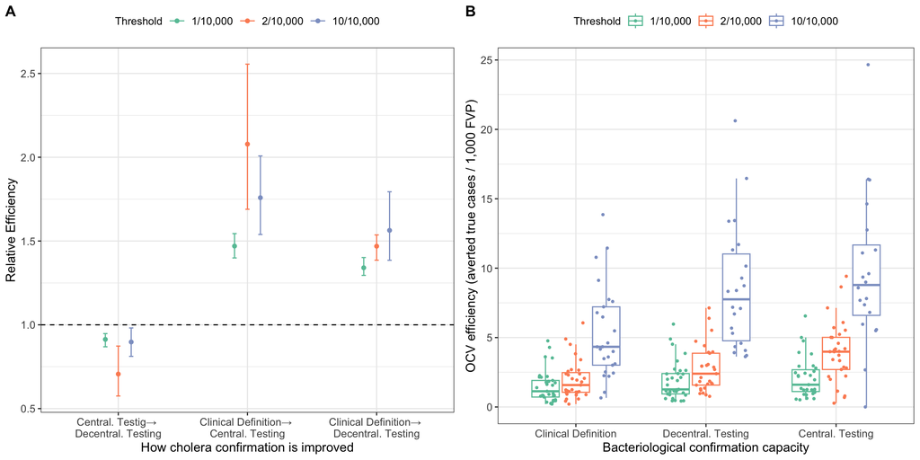

### **Figure S2.** FVP (Decentral. Testing ~ Clinical Definition)

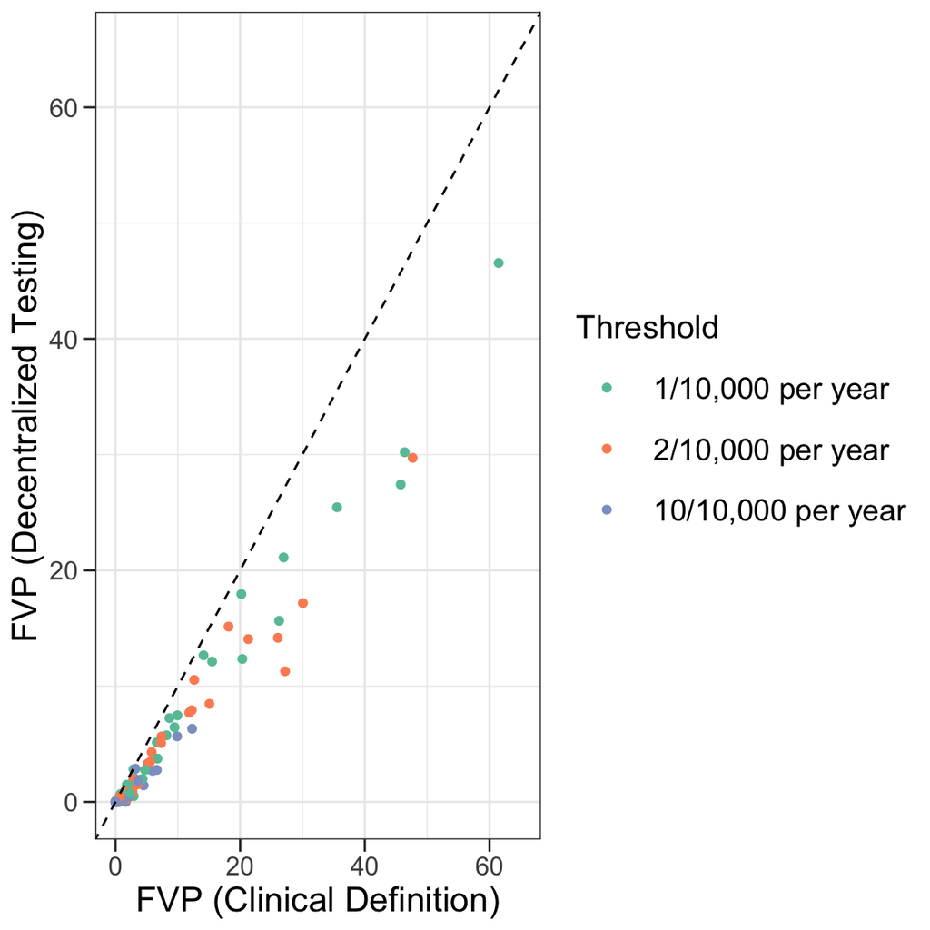

### **Table S1.** Complete public health metrics table

| Metric | Confirmation capacity | Threshold: 1/10,000 Province | Threshold: 1/10,000 District | Threshold: 2/10,000 Province | Threshold: 2/10,000 District | Threshold: 10/10,000 Province | Threshold: 10/10,000 District |
| --- | --- | --- | --- | --- | --- | --- | --- |
| FVPs (million) | Clinical Definition | 616.5 (568-650.6) | 391.8 (378.8-412.2) | 360.7 (341.4-392.5) | 275.2 (264.5-283.9) | 64.8 (52.2-74.4) | 65.2 (59.8-71) |
|  | Decentral. Testing | 368.8 (340.9-409.2) | 274.6 (261.1-285.8) | 198.8 (175.6-223.5) | 165.2 (153.9-179.4) | 14.9 (8.4-28.8) | 30.1 (24.4-37.9) |
|  | Central. Testing | 312.2 (289.4-335.5) | 240.2 (224.3-254.9) | 147.9 (124.8-170.8) | 122.4 (107.3-142.2) | 9.7 (6.9-15.7) | 22.8 (19.3-29.5) |
| Cases averted (million) | Clinical Definition | 0.72 (0.65-0.79) | 0.76 (0.69-0.84) | 0.62 (0.55-0.69) | 0.7 (0.64-0.79) | 0.27 (0.22-0.31) | 0.45 (0.38-0.53) |
|  | Decentral. Testing | 0.63 (0.56-0.7) | 0.71 (0.64-0.8) | 0.5 (0.43-0.57) | 0.62 (0.55-0.71) | 0.13 (0.08-0.19) | 0.33 (0.26-0.41) |
|  | Central. Testing | 0.59 (0.52-0.67) | 0.68 (0.61-0.77) | 0.51 (0.33-0.69) | 0.65 (0.49-0.82) | 0.1 (0.06-0.15) | 0.28 (0.22-0.35) |
| OCV Efficiency (averted cases / 1,000 FVP) | Clinical Definition | 1.2 (1.1-1.3) | 1.9 (1.7-2.2) | 1.7 (1.5-1.9) | 2.6 (2.3-2.8) | 4.2 (3.5-5.1) | 6.9 (6-7.8) |
|  | Decentral. Testing | 1.7 (1.5-1.8) | 2.6 (2.4-2.9) | 2.5 (2.2-2.8) | 3.7 (3.4-4.2) | 8.3 (5.8-13.7) | 10.8 (9.4-12.6) |
|  | Central. Testing | 1.9 (1.7-2.1) | 2.8 (2.6-3.1) | 3.4 (2.4-4.4) | 5.3 (4.1-6.7) | 9.7 (6.8-15.3) | 12 (10.3-14.4) |
| Percent of true cases averted (%) | Clinical Definition | 42.4 (41.7-42.9) | 44.7 (44.3-45.3) | 36.4 (35.2-37.5) | 41.5 (40.8-42.7) | 15.9 (13.6-17.6) | 26.5 (24.4-28.5) |
|  | Decentral. Testing | 36.9 (35.5-38) | 41.8 (41-42.9) | 29.2 (27.3-31) | 36.5 (35.4-38.1) | 7.6 (5.1-10.8) | 19.2 (16.7-22.3) |
|  | Central. Testing | 34.7 (33.2-36.1) | 40 (38.7-41.6) | 29.6 (21.2-37.4) | 38.5 (31.3-44.4) | 6 (3.4-8.5) | 16.4 (13.9-19.4) |
| Percent of vaccinated population living in high incidence rate admins (%) | Clinical Definition | 57.3 (52.9-62.1) | 67.1 (63.4-71.2) | 50.6 (44.5-57.7) | 56.9 (52.9-62.6) | 21.4 (11.5-35.9) | 43.1 (35.2-51.8) |
|  | Decentral. Testing | 98.5 (96.3-99.9) | 98.7 (97.4-99.5) | 98.9 (94.6-100) | 98.1 (95.5-99.3) | 100 (79.7-100) | 97.8 (92.8-100) |
|  | Central. Testing | 98.3 (94.9-99.8) | 96.3 (93-97.9) | 88.9 (76.4-96.8) | 95.5 (91.7-97.6) | 100 (73.7-100) | 94.3 (83-99) |
| Total admins targeted | Clinical Definition | 400 (389-424) | 1580 (1490-1641) | 255 (245-281) | 1067 (1018-1103) | 53 (48-64) | 272 (238-319) |
|  | Decentral. Testing | 256 (242-284) | 1071 (1027-1118) | 146 (133-162) | 655 (620-704) | 19 (14-32) | 130 (107-171) |
|  | Central. Testing | 221 (207-244) | 938 (884-988) | 116 (103-130) | 492 (439-565) | 15 (11-21) | 101 (84-134) |
| Unique admins targeted | Clinical Definition | 157 (151-164) | 607 (573-634) | 104 (99-117) | 427 (406-446) | 26 (23-29) | 119 (105-137) |
|  | Decentral. Testing | 105 (98-117) | 428 (408-449) | 62 (56-69) | 278 (262-290) | 9 (6-15) | 60 (48-76) |
|  | Central. Testing | 91 (85-102) | 381 (354-401) | 51 (45-57) | 209 (187-236) | 7 (5-10) | 48 (39-62) |
| Total countries targeted | Clinical Definition | 28 (27-29) | 31 (30-32) | 24 (23-25) | 30 (29-30) | 12 (11-14) | 21 (18-23) |
|  | Decentral. Testing | 24 (23-26) | 30 (28-31) | 19 (16-21) | 27 (25-29) | 6 (4-9) | 17 (14-19) |
|  | Central. Testing | 23 (21-25) | 29 (28-30) | 17 (15-19) | 26 (23-28) | 5 (4-6) | 15 (13-17) |

### **Table S2.** Complete cost and cost effectiveness table

| Metric | Metric | Confirmation capacity | Threshold: 1/10,000 Province | Threshold: 1/10,000 District | Threshold: 2/10,000 Province | Threshold: 2/10,000 District | Threshold: 10/10,000 Province | Threshold: 10/10,000 District |
| --- | --- | --- | --- | --- | --- | --- | --- | --- |
| Cost | OCV cost ($million) | Clinical Definition | 2909.8 (2680.9-3070.8) | 1849.2 (1788-1945.5) | 1702.4 (1611.5-1852.5) | 1299 (1248.6-1340) | 305.6 (246.6-351) | 307.9 (282.1-335.4) |
|  |  | Decentral. Testing | 1740.8 (1609.1-1931.5) | 1296.3 (1232.3-1349.1) | 938.3 (828.8-1055) | 779.8 (726.2-846.7) | 70.5 (39.8-136) | 142.1 (115.3-179) |
|  |  | Central. Testing | 1473.5 (1365.8-1583.4) | 1133.9 (1058.8-1203.1) | 698.1 (589-806) | 577.7 (506.6-671.1) | 46 (32.6-74.2) | 107.5 (90.9-139.4) |
|  | Test cost ($million) | Clinical Definition | 0 (0-0) | 0 (0-0) | 0 (0-0) | 0 (0-0) | 0 (0-0) | 0 (0-0) |
|  |  | Decentral. Testing | 9.8 (8.3-11.8) | 8.9 (7.7-10.6) | 11 (9.4-13.2) | 9.7 (8.5-11.5) | 14.4 (12.2-17.4) | 12.5 (10.9-14.6) |
|  |  | Central. Testing | 8 (6.8-9.5) | 7.2 (6.3-8.5) | 9.3 (7.8-11.6) | 7.8 (5.5-12.3) | 11.6 (9.8-14.2) | 10.2 (9-11.8) |
|  | Total cost ($million) | Clinical Definition | 2909.8 (2680.9-3070.8) | 1849.2 (1788-1945.5) | 1702.4 (1611.5-1852.5) | 1299 (1248.6-1340) | 305.6 (246.6-351) | 307.9 (282.1-335.4) |
|  |  | Decentral. Testing | 1750.6 (1617.3-1943.3) | 1305.2 (1239.9-1359.6) | 949.3 (838.2-1068.2) | 789.6 (734.7-858.2) | 85 (52-153.4) | 154.6 (126.2-193.5) |
|  |  | Central. Testing | 1481.4 (1372.7-1592.9) | 1141.2 (1065.1-1211.6) | 707.4 (596.8-817.6) | 585.6 (512.1-683.5) | 57.6 (42.4-88.4) | 117.6 (100-151.2) |
| Cost effectiveness | OCV cost per averted case ($) | Clinical Definition | 4011.8 (3694.1-4379.7) | 2451.7 (2152.9-2707.1) | 2759.2 (2494.9-3061.5) | 1841.1 (1657.8-2041.6) | 1128.2 (928.5-1360.9) | 684.8 (603.1-780.3) |
|  |  | Decentral. Testing | 2796.8 (2554.3-3105.8) | 1818.8 (1642.9-2006.5) | 1885.9 (1701.8-2131.8) | 1259.5 (1130-1399.5) | 569.7 (344.2-816.2) | 437.6 (376.1-501.4) |
|  |  | Central. Testing | 2498.4 (2298.6-2740.7) | 1662.5 (1522.8-1796.1) | 1391.7 (1079.2-1960.8) | 894.6 (700.1-1164) | 488.4 (307.7-696) | 392.1 (327.5-456.6) |
|  | Test cost per averted case ($) | Clinical Definition | 0 (0-0) | 0 (0-0) | 0 (0-0) | 0 (0-0) | 0 (0-0) | 0 (0-0) |
|  |  | Decentral. Testing | 12.7 (11.8-14.2) | 10.3 (9.4-11.3) | 18.1 (16-21.1) | 12.9 (11.6-14.3) | 93.1 (60.4-145.2) | 31.2 (25.4-38.6) |
|  |  | Central. Testing | 13.6 (12.4-15.3) | 10.7 (9.6-11.9) | 18.5 (13.9-28.5) | 12.3 (9.3-18.2) | 114.7 (78-206.8) | 36.7 (29.2-47.1) |
|  | Total cost per averted case ($) | Clinical Definition | 4011.8 (3694.1-4379.7) | 2451.7 (2152.9-2707.1) | 2759.2 (2494.9-3061.5) | 1841.1 (1657.8-2041.6) | 1128.2 (928.5-1360.9) | 684.8 (603.1-780.3) |
|  |  | Decentral. Testing | 2809.3 (2566.6-3119.9) | 1828.9 (1652.6-2017.4) | 1904.1 (1719-2148.7) | 1272.1 (1142-1413.4) | 664.8 (433.2-910.6) | 468.3 (404.7-542.8) |
|  |  | Central. Testing | 2512.1 (2311.5-2755) | 1673.2 (1533-1807.3) | 1411.5 (1096.8-1988.4) | 908.2 (709.8-1180.5) | 612.7 (394-868.2) | 429.4 (362.6-501.2) |

### **Table S3.** Number of people tested (cumulatively)

[output not shown]

### **Table S4** Districts excluded from targeting due to small size

- Population here is population size in 2020 (calculated from the raster file);
- Incidence rate here is calculated from the baseline incidence rate (clinical).

| ISO | Province | District | Population Size | Incidence Rate(per million) | Area (km^2) | Bacteriological confirmation Decentralized Testing | Bacteriological confirmation Centralized Testing | Bacteriological confirmation Clinical Definition | Threshold 1/10,000 per year | Threshold 2/10,000 per year | Threshold 10/10,000 per year |
| --- | --- | --- | --- | --- | --- | --- | --- | --- | --- | --- | --- |
| BDI | Bujumbura Mairie | Buyenze | 15,306 | 17.9 | 1.4 |  |  | X | X |  |  |
| BDI | Bujumbura Mairie | Bwiza | 13,977 | 19.0 | 1.4 |  |  | X | X |  |  |
| BDI | Bujumbura Mairie | Kinindo | 29,412 | 33.8 | 6.1 |  |  | X | X |  |  |
| BDI | Bujumbura Mairie | Musaga | 32,816 | 33.8 | 8.5 |  |  | X | X |  |  |
| COD | Ituri | Ariwara | 10,145 | 7.8 | 5.7 |  |  | X | X |  |  |
| COD | Maniema | Lubutu (ville) | 1,235 | 103.3 | 7.6 | X | X | X | X | X | X |
| COD | Maniema | Namoya | 3,116 | 3.7 | 15.3 |  | X | X | X | X |  |
| COD | Tanganyika | Kongolo (ville) | 26,196 | 130.1 | 18.2 | X | X | X | X | X | X |
| COD | Tshopo | Isangi (ville) | 3,825 | 676.8 | 9.7 | X | X | X | X | X | X |
| COD | Tshuapa | Boende (ville) | 340 | 44.2 | 8.3 | X | X | X | X | X |  |
| ETH | Amhara | Bahir Dar Special Zone | 75,160 | 1,316.2 | 8.7 | X | X | X | X | X | X |
| KEN | Nairobi | Embakasi Central | 179,843 | 53.1 | 8.2 |  | X | X | X | X |  |
| KEN | Nairobi | Embakasi North | 129,440 | 53.1 | 5.5 |  | X | X | X | X |  |
| KEN | Nairobi | Kibra | 159,053 | 141.3 | 13.3 | X | X | X | X | X |  |
| KEN | Nairobi | Makadara | 256,086 | 53.1 | 12.1 |  | X | X | X | X |  |
| KEN | Nairobi | Mathare | 103,989 | 53.1 | 2.9 |  | X | X | X | X |  |
| KEN | Nairobi | Ruaraka | 145,641 | 53.1 | 7.2 |  | X | X | X | X |  |
| MWI | Chikwawa | Chikwawa Boma | 2,607 | 68.2 | 8.4 | X | X | X | X | X | X |
| MWI | Chikwawa | Ngabu Urban | 3,382 | 325.2 | 7.8 | X | X | X | X | X | X |
| MWI | Nsanje | Nsanje Boma | 8,828 | 191.2 | 15.7 | X | X | X | X | X | X |
| NAM | Khomas | Katutura Central | 13,585 | 535.3 | 2.0 |  | X | X | X | X | X |
| NAM | Khomas | Moses Garoeb | 39,753 | 535.3 | 33.7 | X | X | X | X | X | X |
| NAM | Khomas | Soweto | 12,620 | 535.3 | 1.9 |  | X | X | X | X | X |
| NGA | Abia | Aba North | 183,819 | 11.5 | 18.1 |  |  | X | X |  |  |
| NGA | Kano | Nassaraw | 451,834 | 20.6 | 19.0 | X |  | X | X | X |  |
| NGA | Oyo | IbadanSouth-East | 319,839 | 45.6 | 23.5 |  |  | X | X | X |  |
| TZA | Rukwa | Lake Rukwa | 1,198 | 5,418.7 | 2,163.9 | X | X | X | X | X | X |
| UGA | Moroto | Moroto | 4,268 | 1,939.0 | 4.8 | X | X | X | X | X | X |

### **Figure S3** Baseline incidence rate of targeted districts

```
## # A tibble: 6 × 4
## # Groups:   Confirmation capacity, threshold [6]
##   `Confirmation capacity` threshold  mean_ir median_ir
##   <chr>                   <fct>        <dbl>     <dbl>
## 1 Clinical Definition     1/10,000  0.000381  0.000142
## 2 Clinical Definition     2/10,000  0.000534  0.000238
## 3 Clinical Definition     10/10,000 0.00150   0.000932
## 4 Decentralized Testing   1/10,000  0.000534  0.000229
## 5 Decentralized Testing   2/10,000  0.000792  0.000399
## 6 Decentralized Testing   10/10,000 0.00247   0.00166
```

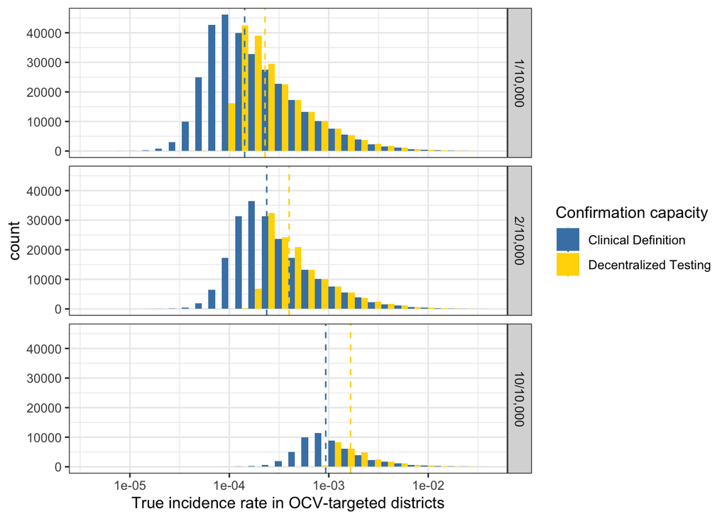

### **Figure S4** Country level gain of OCV efficiency (Clinical definition –> decentralized testing)

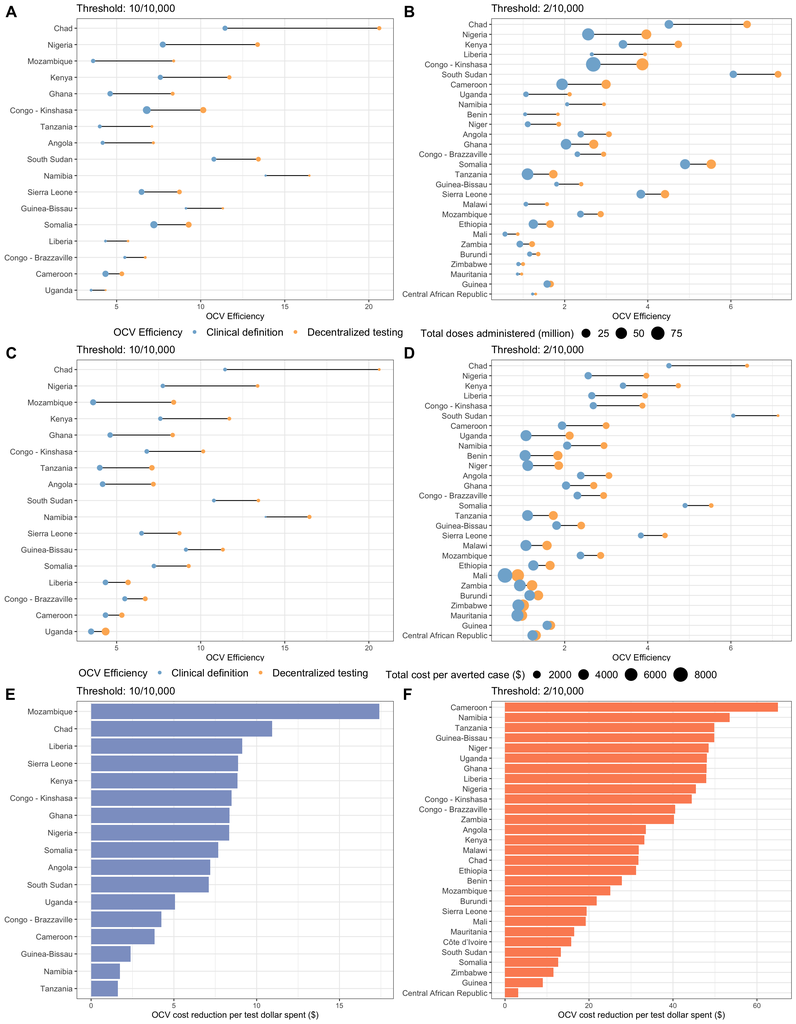